# Probability Distributions for Discrete Random Variables

January 31, 2019

## Obligatory Disclosure

- Ben is an employee of Columbia University, which has received several research grants to develop Stan
- Ben is also a manager of GG Statistics LLC, which uses Stan for business purposes
- According to Columbia University [policy](https://research.columbia.edu/content/conflict-interest-and-research), any such employee who has any equity stake in, a title (such as officer or director) with, or is expected to earn at least \(\$5,000.00\) per year from a private company is required to disclose these facts in presentations

## Bernoulli Distribution

- Tuesday we talked about the Bernoulli distribution over \(\Omega=\left\{ 0,1\right\}\), whose Probability Mass Function (PMF) is \(\Pr\left(\left.x\right|\pi\right)=\pi^{x}\left(1-\pi\right)^{1-x}\), which depends on a possibly unknown probability parameter \(\pi \in \left[0,1\right]\)
- \(\mathbb{E}X = 0\times\left(1-\pi\right) + 1\times\pi = \pi\)
- \(\mathbb{E}\left(X - \pi\right)^2 = \mathbb{E}\left[X^2\right] - \left(\mathbb{E}X\right)^2 = \mathbb{E}X - \pi^2 = \pi - \pi^2 = \pi \left(1 - \pi\right)\)
- You could write a model where \(\pi\) is a function of predictors for each observation, as in \(\pi\left(z\right) = \frac{1}{1+e^{-\alpha - \beta z}}\) for a logit model

## Binomial Distribution

- A Binomial random variable can be defined as the sum of \(n\) INDEPENDENT Bernoulli random variables with the same \(\pi\). What is \(\Omega\) in this case?
- What is an expression for the expectation of a Binomial random variable?
- What is an expression for the variance of a Binomial random variable?
- What is an expression for the PMF, \(\Pr\left(\left.x\right|\pi,n=3\right)\)? Hint: 8 cases to consider
- All succeed, \(\pi^3\) or all fail, \(\left(1 - \pi\right)^3\)
- 1 succeeds and 2 fail \(\pi^1 \left(1-\pi\right)^{3 - 1}\) but there are 3 ways that could happen
- 2 succeed and 1 fails \(\pi^2 \left(1-\pi\right)^{3 - 2}\) but there are 3 ways that could happen
- In general, \(\Pr\left(\left.x\right|n,\pi\right)={n \choose x}\pi^{x} \left(1-\pi\right)^{n-x}\), where \({n \choose x}=\frac{n!}{x!\left(n-x\right)!}\) is the number of ways \(x\) can occur in \(n\) tries (if order is unimportant) where ! indicates the factorial function

## Back to Bowling

- Why is the binomial distribution with \(n = 10\) inappropriate for the first roll of a frame of bowling?
- Could the Bernoulli distribution be used for success in getting a strike?
- Could the Bernoulli distribution be used for the probability of knocking over the frontmost pin?
- If \(X_i = \mathbb{I}\{\mbox{pin i is knocked down}\}\) and \(\pi_i\) is the probability in the \(i\)-th Bernoulli distribution, what conceptually is \[\Pr\left(\left.x_1\right|\pi_1\right)\prod_{i=2}^{10} \Pr\left(\left.x_i\right|\pi_i,X_1=x_1,X_2=x_2,\dots,X_{i-1}=x_{i-1}\right)?\]

## Poisson Distribution for Counts

- Let \(n\uparrow \infty\) and let \(\pi \downarrow 0\) such that \(\mu = n\pi\) remains fixed and finite. What happens to the binomial PMF, \(\Pr\left(\left.x\right|n,\pi\right)={n \choose x}\pi^{x} \left(1-\pi\right)^{n-x}\)?
  - \(\left(1-\pi\right)^{n-x} = \left(1-\frac{\mu}{n}\right)^{n-x} = \left(1-\frac{\mu}{n}\right)^n \times \left(1-\frac{\mu}{n}\right)^{-x} \rightarrow e^{-\mu} \times 1\)
  - \({n \choose x}\pi^{x} = \frac{n!}{x!\left(n - x\right)!} \frac{\mu^x}{n^x} = \frac{n \times \left(n - 1\right) \times \left(n - 2\right) \times \dots \times \left(n - x + 1\right)} {n^x} \frac{\mu^x}{x!} \rightarrow 1 \times \frac{\mu^x}{x!}\)
  - Thus, \(\Pr\left(\left.x\right|\mu\right) = \frac{\mu^xe^{-\mu}}{x!}\) is the PMF of the Poisson distribution over \(\Omega = \{0,\mathbb{Z}_+\}\), which is a common distribution for count variables
- What is the variance of a Poisson random variable?

## Parameterized Bowling

- Bell numbers are defined as \(\mathcal{B}_0 = 1\), \(\mathcal{B}_1 = 1\), and else \(\mathcal{B}_{n + 1} = \sum_{k = 0}^n {n \choose k} \mathcal{B}_k\)
- Let \(\Pr\left(\left.x\right|n, \Upsilon\right) = \frac{{n + \Upsilon \choose x + \Upsilon} \mathcal{B}_{x + \Upsilon}} {\mathcal{B}_{n + 1 + \Upsilon} \ - \sum_{k = 0}^{\Upsilon - 1} {n + \Upsilon \choose k} \mathcal{B}_k}\) where \(\Upsilon \in \{0,\mathbb{N}_+\} = \Theta\) is an unknown
- Use a Poisson distribution with expectation \(\mu\) to represent beliefs about \(\Upsilon\)
- Can update those beliefs with data on pins knocked down in bowling

```r
B <- Vectorize(memoise::memoise(numbers::bell)) # makes it go faster
Pr <- function(x, n = 10, Upsilon = 0) { # probability of knocking down x out of n pins
  stopifnot(length(n) == 1, is.numeric(x), all(x == as.integer(x)))
  numer <- B(x + Upsilon) * choose(n + Upsilon, x + Upsilon)
  denom <- B(n + 1 + Upsilon) # ^^^ choose(n, k) is n! / (k! * (n - k)!)
  if(Upsilon > 0) denom <- denom -
    sum(choose(n + Upsilon, 0:(Upsilon - 1)) * B(0:(Upsilon - 1)))
  return(ifelse(x > n, 0, numer / denom))
}
```

## How to Select \(\mu\) in the Poisson Prior?

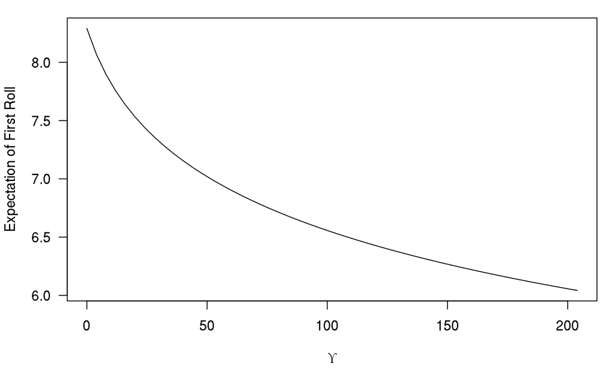

## Using Bayes Rule with Bowling Data

```r
frames <- cbind(x_1 = c(9, 8, 10, 8, 7, 10,  9, 6, 9),
                x_2 = c(1, 1,  0, 2, 2,  0,  0, 3, 0))
```

- Suppose that you observe the first \(J = 9\) frames of bowling on the same person. Your posterior beliefs about \(\Upsilon\) are given by  
  \[\Pr\left(\left.\Upsilon\right|x_{1,1},x_{1,2},\dots,x_{J,1},x_{J,2},\mu\right) = \frac{\Pr\left(\left.\Upsilon\right|\mu\right) \Pr\left(\left.x_{1,1},x_{1,2},\dots,x_{J,1},x_{J,2}\right|\Upsilon\right)} {\Pr\left(x_{1,1},x_{1,2},\dots,x_{J,1},x_{J,2}\right)}\]
- \(\Pr\left(\left.\Upsilon\right|\mu\right) = \frac{\mu^\Upsilon e^{-\mu}}{\Upsilon!}\) is the PMF for a Poisson distribution
- What is \(\Pr\left(\left.x_{1,1},x_{1,2},\dots,x_{J,1},x_{J,2}\right|\Upsilon\right)\)?
- Due to the independence of frames, \(\Pr\left(\left.x_{1,1},x_{1,2},\dots,x_{J,1},x_{J,2}\right|\Upsilon\right) =\) \(\prod_{j=1}^J\Pr\left(\left.x_{j,1}\right|n = 10, \Upsilon\right) \Pr\left(\left.x_{j,2}\right|n=10-x_{j,1}, \Upsilon\right)\)
- What is \(\Pr\left(x_{1,1},x_{1,2},\dots,x_{J,1},x_{J,2}\right)\)?

## Denominator of Bayes Rule

- \(\Pr\left(x_{1,1},x_{1,2},\dots,x_{J,1},x_{J,2}\right) = \mathbb{E}g\left(\Upsilon\right)\) w.r.t. the prior PMF \(\Pr\left(\left.\Upsilon\right|\mu\right)\), where \(g\left(\Upsilon\right) = \Pr\left(\left.x_{1,1},x_{1,2},\dots,x_{9,1},x_{9,2}\right|\Upsilon\right)\). \(g\left(\Upsilon\right)\) called the LIKELIHOOD function of \(\Upsilon\) (evaluated at the observed data)
- The expected likelihood can be computed in this case as \[\mathbb{E}g\left(\Upsilon\right) = \sum_{i=0}^\infty \Pr\left(\left.i\right|\mu\right) \Pr\left(\left.x_{1,1},x_{1,2},\dots,x_{J,1},x_{J,2}\right|\Upsilon = i\right) =\\ \sum_{i=0}^\infty \frac{\mu^{i}e^{-\mu}}{i!}\prod_{j=1}^J \Pr\left(\left.x_{j,1}\right|n = 10, \Upsilon = i\right) \Pr\left(\left.x_{j,2}\right|n=10-x_{j,1}, \Upsilon = i\right)\]
- In practice, when evaluating an infinite sum we just stop once the terms get close enough to zero

## Calculating Posterior Probabilities in R

```r
mu <- 100                 # for example, can be any positive real number
Theta <- 0:207            # 207 is the biggest a laptop can handle
prior <- dpois(Theta, mu) # dpois() is the Poisson PMF
numer <- prior * sapply(Theta, FUN = function(i) { # sapply applies the given function
  J <- nrow(frames)                                # to each element of the first argument
  Pr_game <- Pr(frames[ , "x_1"], n = 10, Upsilon = i) * sapply(1:J, FUN = function(j)
             Pr(frames[j, "x_2"], n = 10 - frames[j, "x_1"], Upsilon = i))
  prod(Pr_game)
})
post <- numer / sum(numer)
```

```r
barplot(prior, names.arg = Theta, col = 2, ylim = range(post))
barplot(post, names.arg = Theta, col = 3)
```

## Comparison of Prior and Posterior Probabilities

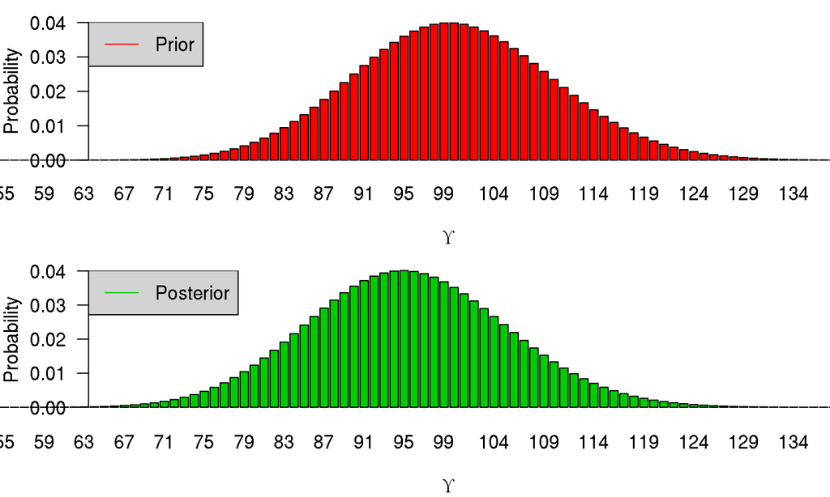

## Hypergeometric Distribution

- The binomial distribution corresponds to sampling WITH replacement
- The hypergeometric distribution corresponds to sampling WITHOUT replacement and has PMF \(\Pr\left(\left.x\right|N,K,n\right) = \frac{{K \choose x}{N - K \choose n - x}}{{N \choose n}}\) where
  - \(N\) is the (finite) size of the set being drawn from
  - \(K\) is the number of successes in that finite set
  - \(n\) is the number of times you draw without replacement
- What is the probability of drawing two cards from a deck with the same value?
- Intuitively, the probability of any pair should be \(\frac{4}{52}\times\frac{3}{51} = \frac{1}{221}\) and there are \(13\) ways to do that so `13 * dhyper(x = 2, 4, 52 - 4, 2)`

## Categorical Distribution

- The categorical distribution over \(\Omega = \{1,2,\dots,K\}\) has a PMF \(\Pr\left(\left.x\right|\pi_1,\pi_2,\dots,\pi_K\right) = \prod_{k=1}^K \pi_k^{\mathbb{I}\left(x=k\right)}\) where the parameters satisfy
  1. \(\pi_k \geq 0 \forall k\)
  2. \(\sum_{k=1}^K \pi_k = 1\)
- The categorical distribution is a generalization of the Bernoulli distribution to the case where there are \(K\) categories rather than merely failure vs. success
- To draw randomly from it, you can do `sample(Omega, size = 1, prob = c(pi_1, pi_2, ..., pi_K))`
- You can make each \(\pi_k\) a function of predictors in a regression model

## Multinomial Distribution

- The multinomial distribution over \(\Omega = \{0,1,\dots,n\}\) has a PMF \(\Pr\left(\left.x\right|\pi_1,\pi_2,\dots,\pi_K\right) = n!\prod_{k=1}^K \frac{\pi_k^{x_k}}{x_k!}\) where the parameters satisfy \(\pi_k \geq 0 \forall k\), \(\sum_{k=1}^K \pi_k = 1\), and \(n = \sum_{k=1}^K x_k\)
- The multinomial distribution is a generalization of the binomial distribution to the case that there are \(K\) possibilities rather than merely failure vs. success
- The multinomial distribution is the count of \(n\) independent categorical random variables with the same \(\pi_k\) values
- Can draw from it with `rmultinom(1, size = n, prob = c(pi_1, pi_2, ..., pi_K))`
- Categorical is a special case where \(n = 1\)

## Objectivity and Subjectivity

- Under weak and not particularly controversial assumptions, Bayesian inference is THE objective way to update your beliefs about (functions of) \(\theta\) in light of new data \(y_1, y_2, \dots, y_N\)
- Nevertheless, the Bayesian approach is labeled subjective because it does not say what your beliefs about \(\theta\) should be before you receive \(y_1, y_2, \dots, y_N\)
- Thus, if you currently believe something absurd about \(\theta\) now, your beliefs about \(\theta\) will merely be less absurd after updating them with \(y_1, y_2, \dots, y_N\)
- The big problem is not that people believe wrong things now, but that they do not update their beliefs about \(\theta\) according to Bayesian principles when they observe \(y_1, y_2, \dots, y_N\)
- In fact, in some situations, observing data that contradicts people’s previous beliefs makes them believe in their wrong beliefs more strongly
- Bayesian principles are also used in formal models, but as an assumption about how people should behave rather than a behavioral description

## (Dis)Advantages of Bayesian Inference

- Bayesian inference remains useful in situations other paradigms specialize in:
  - Experiments: What are your beliefs about the ATE after seeing the data?
  - Repeated designs: Bayesian estimates have correct frequentist properties
  - Predictive modeling: If you only care about predictions, use the posterior predictive distribution
- Bayesian inference is very useful when you are using the results to make a decision or take an action; other paradigms are not
- Bayesian inference is orders of magnitude more difficult for your computer because it is attempting to answer a more ambitious question
- The Bayesian approach is better suited for convincing yourself of something than convincing other people